# Report VCT/PCT task results

# Statistical Analysis

This is a document that converts the results of the PCT (so far) to prose.

A Bayesian logistic regression was run `language ~ stim_language*phoneme*frame + (1 | participant), data = all_pct)`, where the outcome was language (either English or Spanish, coded as 1 and 0). The preditors were `stim_language` (either French or German), `phoneme` (i, o, schwa or y) and `frame` (fricative or bilabial).

The priors were the default (weakly informative priors), and the model was run using brms using all other defaults.

# Results

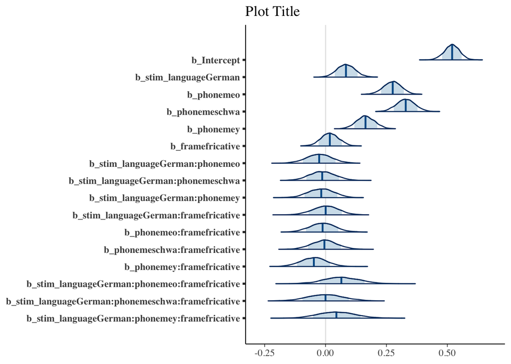

Number of participants

```
## [1] 46
```

List of each participant with number of trials each

| participant | n |
| --- | --- |
| 5ab33d98580b990001730708 | 80 |
| 5c05922f4e1b7b00016af702 | 80 |
| 5e3f7b673ba9991dc9cabcfa | 80 |
| 5e9fdd5effe6a51855448d1b | 80 |
| 5ec2a21d6053200957b486f9 | 80 |
| 5eecf71ff9be240d72d2dddf | 80 |
| 5f2f5ffc7144073520501a57 | 80 |
| 5f320f52f0468e14718b7f7a | 80 |
| 5f3cc983e81de700092fa67e | 80 |
| 5f5d6c3cbacc025bf0a03440 | 80 |
| 5f66457793e8240d22e60ea3 | 80 |
| 5f740f60b8a1e41acc020269 | 80 |
| 601584d717cbb906851646b7 | 80 |
| 60183e25b4423c05ee0ee791 | 80 |
| 6036e5c365451fffd2c800b2 | 80 |
| 6062d6036cdaef33b66e7f62 | 80 |
| 60a4cadc8c4109eeeb9fda14 | 80 |
| 60b805f47d6292141781c36e | 80 |
| 611023befc2052d878c7f50c | 80 |
| 61135eb097c6eb84381896ac | 80 |
| 613a3838d8479f4bc5723974 | 80 |
| 613a4182d75ec66fcd3292e9 | 80 |
| 613a4fe3a0971a14d7c0c8ab | 80 |
| 613a59b4554295dbdaa5dc24 | 80 |
| 613a68a9f9bc0d833831eff0 | 80 |
| 613a69d8ed1c11f70b3d37c7 | 80 |
| 613a886056265d62028d15d2 | 80 |
| 613a8edf1dccc076d9b59330 | 80 |
| 613add879e40150ca89fd051 | 80 |
| 613af18151be953036664b9a | 80 |
| 613b8c9719c838f7c5e7297c | 80 |
| 61400425790ab5dbef568393 | 80 |
| 614215e5a85111f66a9abbfc | 80 |
| 6142883565f2f12724b5e613 | 80 |
| 6144e07daad38d78db932d30 | 80 |
| 6145448f8b3cd18fb19f0b0e | 80 |
| 614d05f9b577ed47c8b6db75 | 80 |
| 6151cfe3ba49dd3ad62708ee | 80 |
| 615ccde70c1ce067fc831306 | 80 |
| 616ed97200b22fa9725353b3 | 80 |
| 6176c86c754429f29f4e83ea | 80 |
| Al | 80 |
| Alan | 80 |
| Hector Sanchez | 80 |
| paola | 80 |
| NA | 640 |

Number of responses per language across all stimuli

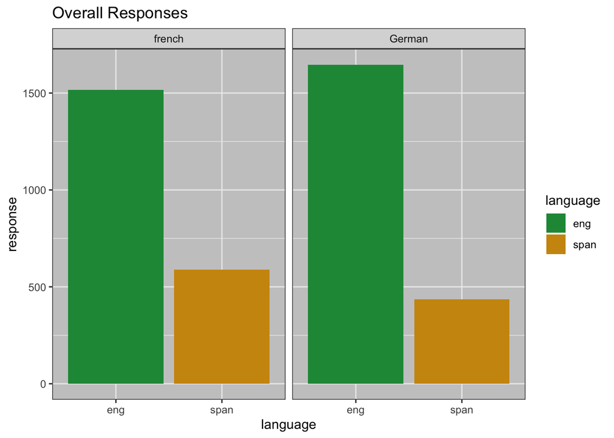

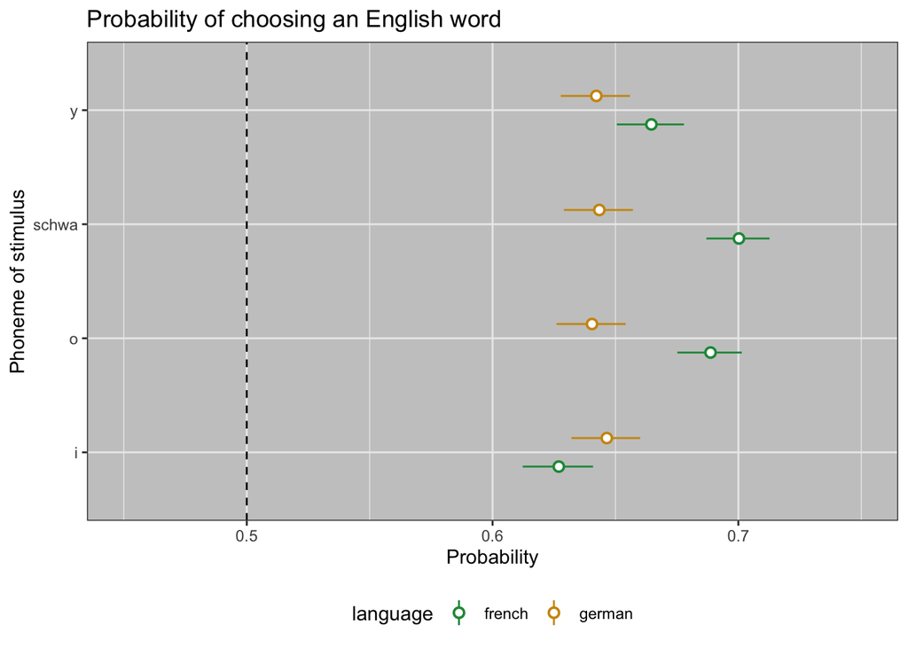

# check how many phonemes total were presented

```
## # A tibble: 4 x 2
##   phoneme     n
##   <chr>   <int>
## 1 i        1060
## 2 o        1060
## 3 schwa    1060
## 4 y        1060
```

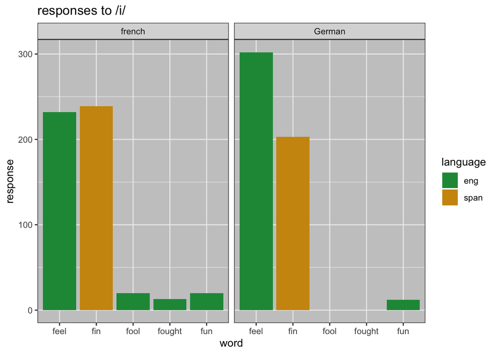

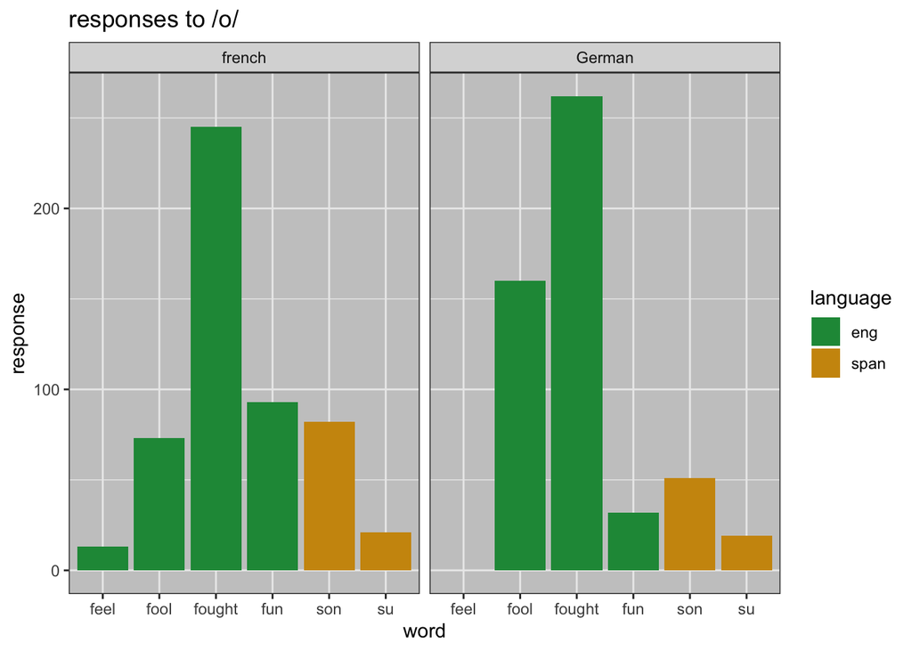

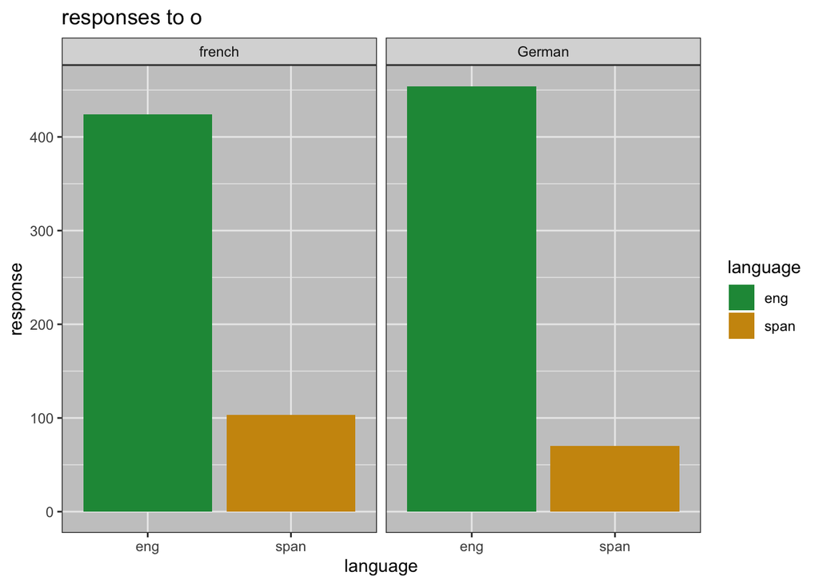

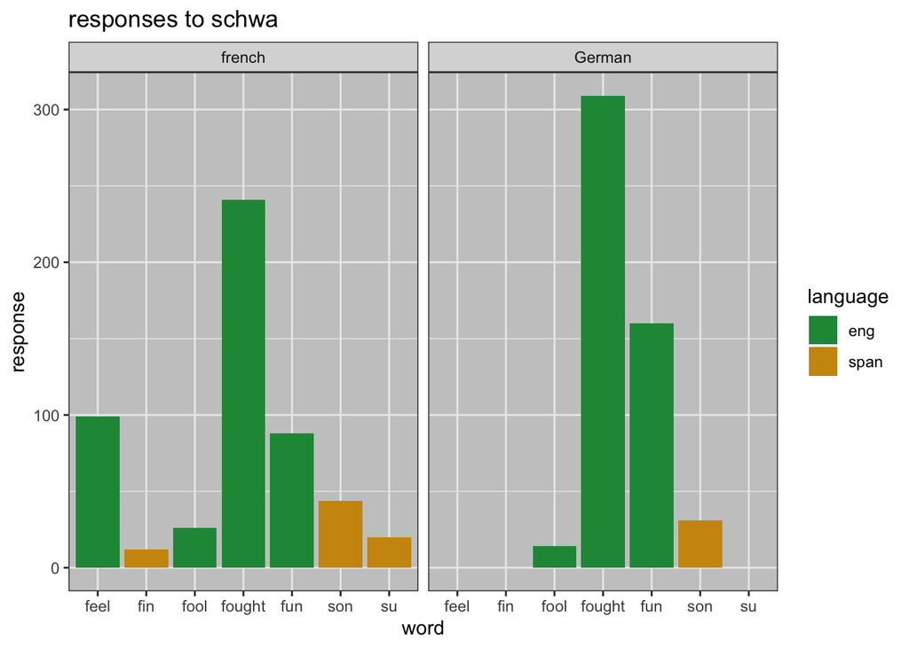

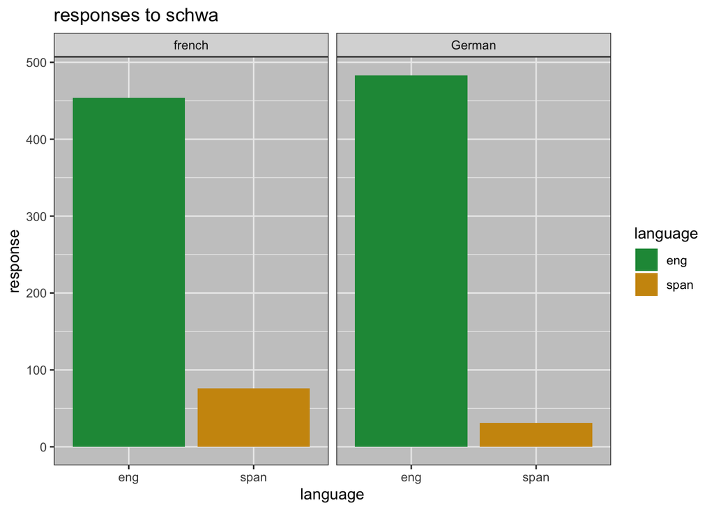

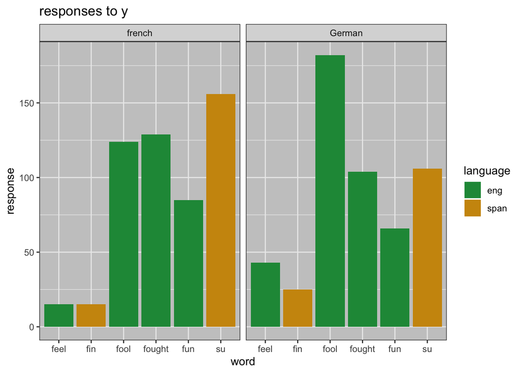